# Homework Chapter 10

Jinhong Du 15338039

### 10.9 Refer to **Brand preference** Problem 6.5.

#### a. Obtain the studentized deleted residuals and identify any outlying $Y$ observations. Use the Bonferroni outlier test procedure with $\alpha = .10$. State the decision rule and conclusion.

```r
data1 <- read.table("CH06PR05.txt",head=FALSE,col.names = c('Y',
'X1','X2'))
Y <- data1$Y
X1 <- data1$X1
X2 <- data1$X2
n = length(Y)
X <- cbind(rep(1,n),X1,X2)
fit1 <- lm('Y~X1+X2',data=data1)
e <- fit1$residuals
df_ <- fit1$df.residual
SSE <- sum(e^2)
h <- diag(X%*%solve(crossprod(X))%*%t(X))
t <- e*sqrt(df_-1)/sqrt(SSE*(1-h)-e^2)
tab <- as.table(cbind(
  'e' = e,
  't' = t
))
round(t(tab), 4)
```

```
##         1       2       3       4       5       6       7       8       9
## e -0.1000  0.1500 -3.1000  3.1500 -0.9500 -1.7000 -1.9500  1.3000  1.2000
## t -0.0409  0.0613 -1.3606  1.3860 -0.3669 -0.6649 -0.7672  0.5046  0.4651
##        10      11      12      13      14      15      16
## e -1.5500  4.2000  2.4500 -2.6500 -4.4000  3.3500  0.6000
## t -0.6044  1.8230  0.9778 -1.1397 -2.1027  1.4897  0.2457
```

```r
print(sprintf('t(%f;%d)=%f',1-0.1/2/n,df_,qt(1-0.1/2/n,df_)))
```

```
## [1] "t(0.996875;13)=3.256463"
```

```r
print(sprintf('max{|t_i|}=%f',max(abs(t))))
```

```
## [1] "max{|t_i|}=2.102726"
```

$$\begin{align*}
d_i&=Y_i-\hat{Y}_{i(i)}\\
&=\dfrac{e_i}{1-h_{ii}}\\
s\{d_i\}&= MSE_{(i)}[1+X_i^T(X^T_{(i)}X_{(i)})^{-1}X_i]\\
&=\dfrac{MSE_{(i)}}{1-h_{ii}}\\
t_i&=\dfrac{d_i}{s\{d_i\}}\\
&=\dfrac{e_i}{\sqrt{MSE_{(i)}(1-h_{ii})}}\\
&=\dfrac{e_i\sqrt{n-p-1}}{\sqrt{SSE(1-h_{ii})-e^2_i}}\sim t(n-p-1)
\end{align*}$$

$$H_0:(X_i,Y_i) \text{ is an outlier}\qquad H_a:(X_i,Y_i) \text{ is not an outlier}$$
the test statistic is $t_i$.

Given $\alpha$, the decision rule is

If $|t_i|\geqslant t(1-\frac{\alpha}{2n};n-p),$ then conclude $H_0$;

If $|t_i|< t(1-\frac{\alpha}{2n};n-p),$ then conclude $H_a$;

Here, $\max\limits_i\{|t_i|\}=2.102726<t(0.996875;13)=3.256463$, therefore, conclude $H_a$, i.e. there is no outlier.

#### b. Obtain the diagonal elements of the hat matrix, and provide an explanation for the pattern in these elements.

```r
print(h)
```

```
##  [1] 0.2375 0.2375 0.2375 0.2375 0.1375 0.1375 0.1375 0.1375 0.1375 0.1375
## [11] 0.1375 0.1375 0.2375 0.2375 0.2375 0.2375
```

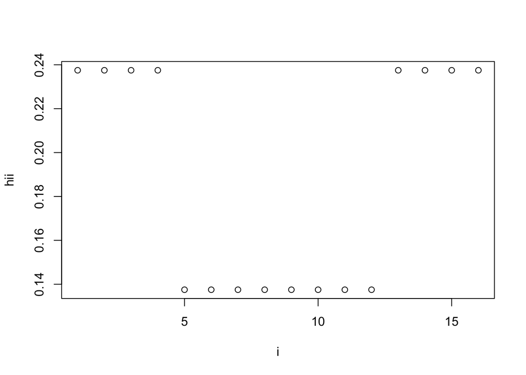

```r
plot(c(1:n),h,xlab = 'i',ylab='hii')
```

Half $h_{ii}=0.2375$ and the others equal to $0.1375$. It means that the data can be equally divided into 2 groups. In each of these group, the distances between the data and the regression surface are the same.

#### c. Are any of the observations outlying with regard to their $X$ values according to the rule of thumb stated in the chapter?

```r
p = n-df_
print(2*p/n)
```

```
## [1] 0.375
```

Since $\frac{2p}{n}=0.375>0.2375=\max\limits_i\{h_{ii}\}$, there is no observation outlying with regard to their $X$ values.

#### g. Calculate Cook’s distance $D_i$ for each case and prepare an index plot. Are any cases influential according to this measure?

```r
MSE <- SSE/df_
D <- e^2 /p/MSE*h/((1-h)^2)
print(D)
```

```
##            1            2            3            4            5
## 0.0001877130 0.0004223542 0.1803921815 0.1862582123 0.0076655286
##            6            7            8            9           10
## 0.0245466787 0.0322971439 0.0143542862 0.0122308711 0.0204060192
##           11           12           13           14           15
## 0.1498281704 0.0509831969 0.1318214458 0.3634123447 0.2106609008
##           16
## 0.0067576676
```

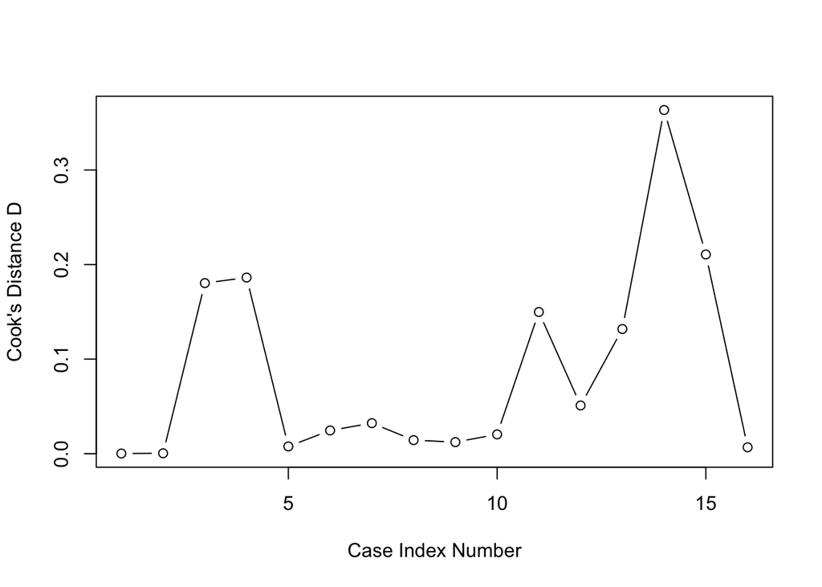

```r
plot(c(1:n),D,'b',xlab = 'Case Index Number',ylab='Cook\'s Distance D')
```

$$\begin{align*}
D_i&=\dfrac{\sum\limits_{j=1}^n(\hat{Y}_j-\hat{Y}_{j(i)})^2}{pMSE}\\
&=\dfrac{e^2_ih_{ii}}{pMSE(1-h_{ii})^2}
\end{align*}$$

For a small data set, all $D_i$ is less than $1$. Therefore, there is no cases influential according to this measure.

### 10.13 **Cosmetics sales**. An assistant in the district sales office of a national cosmetics firm obtained data, shown below, on advertising expenditures and sales last year in the district’s $44$ territories. $X_1$ denotes expenditures for point-of-sale displays in beauty salons and department stores (in thousand dollars), and $X_2$ and $X_3$ represent the corresponding expenditures for local media advertising and prorated share of national media advertising, respectively. $Y$ denotes sales (in thousand cases). The assistant was instructed to estimate the increase in expected sales when $X_1$ is increased by $1$ thousand dollars and $X_2$ and $X_3$ are held constant, and was told to use an ordinary multiple regression model with linear terms for the predictor variables and with independent normal error terms.

#### a. State the regression model to be employed, and fit it to the data.

```r
data2 <- read.table("CH10PR13.txt",head=FALSE,col.names = c('Y',
'X1','X2','X3'))
Y <- data1$Y
X1 <- data2$X1
X2 <- data2$X2
X3 <- data2$X3
n = length(Y)
fit2 <- lm('Y~X1+X2+X3',data=data2)
summary(fit2)
```

```
##
## Call:
## lm(formula = "Y~X1+X2+X3", data = data2)
##
## Residuals:
##     Min      1Q  Median      3Q     Max
## -5.4217 -0.9115  0.0703  1.1420  3.5479
##
## Coefficients:
##             Estimate Std. Error t value Pr(>|t|)
## (Intercept)   1.0233     1.2029   0.851   0.4000
## X1            0.9657     0.7092   1.362   0.1809
## X2            0.6292     0.7783   0.808   0.4237
## X3            0.6760     0.3557   1.900   0.0646 .
## ---
## Signif. codes:  0 '***' 0.001 '**' 0.01 '*' 0.05 '.' 0.1 ' ' 1
##
## Residual standard error: 1.825 on 40 degrees of freedom
## Multiple R-squared:  0.7417, Adjusted R-squared:  0.7223
## F-statistic: 38.28 on 3 and 40 DF,  p-value: 7.821e-12
```

```r
print(fit2$fitted.values)
```

```
##         1         2         3         4         5         6         7
## 12.523331 11.247489  9.232069 12.005132  8.594978 12.861599 15.557943
##         8         9        10        11        12        13        14
##  9.971563  7.134733  7.893822 11.358116  7.858766  5.889261 11.179547
##        15        16        17        18        19        20        21
##  8.541178  2.974351  6.328273 10.691463  7.226361 10.817552  9.962447
##        22        23        24        25        26        27        28
##  8.217182  4.404481 12.971120  8.623391  9.705286 11.580732  9.295027
##        29        30        31        32        33        34        35
## 12.812187  8.381651  5.989922  5.777189 11.658598  3.133836  9.459454
##        36        37        38        39        40        41        42
## 10.213518 16.930693  7.134775  6.559452  6.221696  8.324271  9.802153
##        43        44
##  9.014906 13.198505
```

The regression model is
$$Y=1.0233+0.9657X_1+0.6292X_2+0.6760X_3+\epsilon$$

#### b. Test whether there is a regression relation between sales and the three predictor vruiables; use $\alpha = .05$. State the alternatives, decision rule, and conclusion.

```r
fit2.aov <- anova(fit2)
SSR <- sum(fit2.aov[1:2, 2])
SSE <- sum(fit2$residuals^2)
F <- (SSR)/(3-1)/(SSE/fit2$df.residual)
print(sprintf('F*=%f',F))
```

```
## [1] "F*=55.613439"
```

```r
print(sprintf('F(0.95;%d,%d)=%f',3-1,fit2$df.residual,df(0.95,3-1,fit2$df.residual)))
```

```
## [1] "F(0.95;2,40)=0.377368"
```

$$H_0:\beta_1=\beta_2=\beta_3=0\qquad H_a: \text{not all }\beta_k=0\ (k=1,2,3)$$
The test statistic is
$$\begin{align*}
F^*&=\dfrac{\frac{SSR(X_1,X_2,X_3)}{p-1}}{\frac{SSE(X_1,X_2,X_3)}{n-p}}\\
&=\dfrac{MSR}{MSE}
\end{align*}$$

Given $\alpha$, the decision rule is

If $F^*> F(1-\alpha;2,40),$ then conclude $H_a$;

#### c. Test for each of the regression coetficients $\beta_k (k = 1, 2, 3)$ individually whether or not $\beta_k = 0$; use $\alpha = .05$ each time. Do the conclusions of these tests correspond to that obtained in part (b)?

```r
SSE123 <- sum(fit2$residuals^2)
SSR1_23 <- sum(lm('Y~X2+X3',data=data2)$residuals^2)-SSE123
SSR2_13 <- sum(lm('Y~X1+X3',data=data2)$residuals^2)-SSE123
SSR3_12 <- sum(lm('Y~X1+X2',data=data2)$residuals^2)-SSE123
F1 <- SSR1_23/(SSE123/fit2$df.residual)
F2 <- SSR2_13/(SSE123/fit2$df.residual)
F3 <- SSR3_12/(SSE123/fit2$df.residual)
print(sprintf('When k=1, F*=%f',F1))
```

```
## [1] "When k=1, F*=1.854008"
```

```r
print(sprintf('When k=2, F*=%f',F2))
```

```
## [1] "When k=2, F*=0.653481"
```

```r
print(sprintf('When k=3, F*=%f',F3))
```

```
## [1] "When k=3, F*=3.611251"
```

```r
print(sprintf('F(0.95;%d,%d)=%f',1,fit2$df.residual,df(0.95,1,fit2$df.residual)))
```

```
## [1] "F(0.95;1,40)=0.251396"
```

For $k=1,2,3$,
$$H_0:\beta_k=0\qquad H_a: \beta_k\neq 0$$
The test statistic is
$$\begin{align*}
F^*&=\dfrac{\frac{SSR(X_k|X_j,\text{ for }j=1,2,3,\ j\neq k)}{1}}{\frac{SSE(X_1,X_2,X_3)}{n-p}}\\
&=\dfrac{MSR(X_k|X_j,\text{ for }j=1,2,3,\ j\neq k)}{MSE(X_1,X_2,X_3)}
\end{align*}$$

Given $\alpha$, the decision rule is

If $F^*\leqslant F(1-\alpha;1,40),$ then conclude $H_0$;

If $F^*> F(1-\alpha;1,40),$ then conclude $H_a$;

#### d. Obtain the correlation matrix of the $X$ variables.

```r
cor(cbind(X1,X2,X3))
```

```
##           X1        X2        X3
## X1 1.0000000 0.9744313 0.3759509
## X2 0.9744313 1.0000000 0.4099208
## X3 0.3759509 0.4099208 1.0000000
```